# Part II: Explanatory Data Analysis - Prosper Loan

By

### Nishanth Iruthayaraj

## Summary of Findings

- This data set contains 113,937 loans with 81 variables on each loan, including loan amount, borrower rate (or interest rate), current loan status, borrower income, and many others.
- We perform some preliminary wrangling and start exploring the features of the dataset as univariate, bivariate and multivariate exploration.

##### Obervation of Univariate exploration:

- What are the findings of main feature of interest?
  - The distribution of Borrower's Annual Percentage Rate (APR) is a multimodal. In addition, there is an unusual spike in the percentage rate around 0.36.
- What are the findings of other features supporting the investigation?
  - The most frequent loan term is 36 months. The 60 months loan term stands in the second position. But the loan term for 12 months is very very less. It shows that only very few borrowers take loan for short term.
  - Many of the loan are in current status. Also there are many loans that has been Completed, Chargedoff and Deafaulted.
  - Past Due (based on days) and the Cancellation (5 counts) status are very minimum comapred to the other loan status.
  - The interest rate has the multimodal distribution
  - It looks also similar to the distribution of varibale `borrower_APR`
  - There are huge amount of borrowers has very highest risk score (0).
  - The most of the prosper score of the borrowers lies between the range of 2 and 10.
  - Debt Consolidation is the most frequent loan category that the borrowers applied for
  - The most the borrowers applied for loan are "Employed"
  - Surprisingly, there are equal amount of borrowers i.e: even if the Borrower has their own home or not, the loan Borrowers are almost equal.
  - The most common range of borrower's income is between the range of 2500 and 500.
  - The income distribution of the borrowrs are right skewed
  - The approximate maximum income lies around 42000
  - The most common loan amount taken by the borrowers is approximately 4500
  - The distribution of the loan amount is also right skewed with multiple spikes

##### Obervation of Bivariate exploration:

- How is the main feature of interest related to other variable and how does main feature varies with other features of interest?
  - The Annual Percentage Rate (APR) of Borrowers is decreasing when the loan original amount increases i.e. the `borrower_APR` is negatively correlated with respect to `loan_original_amount`. Also the length of the `term` increase when there is an increase in the `loan_original_amount`. When the Borrowers has higher monthly income, they are capable of getting the high loan amount and can afford to payback the loan amount on monthly basis.
  - In addition to the above relationships between the features, we can see that the Homeowner has the higher employment rate while comapring to borrowers who doesn't own home. Also The maximam amount of loan take by Homeowner is around 35000 and the Non-Homeowner has around 25000. This also proves that the borrowers can take more loan amount when they own some properties.

##### Obervation of Multivariate exploration:

In the further presentation, the readers can see the visualization for about summary with polished plots

##### What is the structure of your dataset?

The prosper loan dataset structure is 113,937 loans and 81 variables (can be found found using `df_prosper2.shape`). But I have chosen 14 variables required for our exploratory data analysis.

##### What is/are the main feature(s) of interest in your dataset?

The significant feature of interest in the dataset is the `borrower_APR` feature. `borrower_rate` can also be another vital feature.

##### What features in the dataset do you think will help support your investigation into your feature(s) of interest?

I think that the features such as 'term', 'loan_status', 'borrower_APR', 'borrower_rate', 'prosper_score', 'listing_category_numeric', 'employmentstatus', 'employment_status_duration', etc., will help support my investigation into feature of interest (`borrowers_APR`)

## Univariate Exploration

In this section I explore the univariate data and find the insights by visualizing distribution for all the chosen varibles individually. I have followed "Question-Visualization-Observation" framework to make our exploration clean and tidy. Firstly, I have shown the main feature of interest and then visualizing some other important features by following the order of varibales in our new dataframe.

##### Visualization 1:

`borrower_APR`: The Borrower's Annual Percentage Rate (APR) for the loan.

Question: What type of distribution does the feature of interest has?

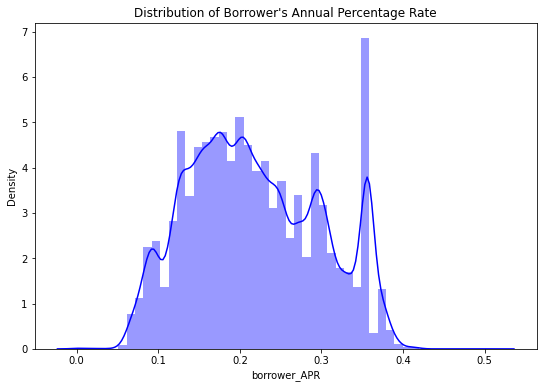

Observation:

- It is clear that the distribution of Borrower's Annual Percentage Rate (APR) is a multimodal
- The borrower_APR has highest percentage rate around 0.36

##### Visaulization 10:

`loan_original_amount`: The origination amount of the loan.

Question: What is the most common loan amount taken by the borrowers?

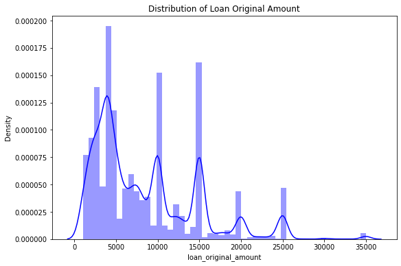

Observation:

- The most common loan amount taken by the borrowers is approximately 4500
- The distribution of the loan amount is also right skewed with multiple spikes

## Bivariate Exploration

In this section, we will continue our exploration for two variables. In this bivariate exploration, we can see the visulaization of varibles that plays a vital role in investigation.

##### Visualization 12:

`borrower_APR` vs `loan_original_amount`

Question: Does the higher loan amount has an impact on Borrower's APR?

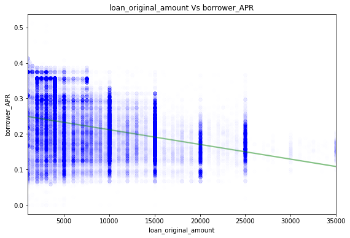

Observation:

- The visualization states that the Annual Percentage Rate (APR) of Borrowers is defintely decrease when the loan original amount increases.

##### Visualization 16:

`stated_monthly_income` vs `loan_original_amount`

Question: How does the Monthly Income related to Loan Amount?

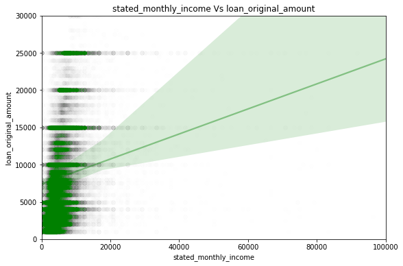

Observation:

- The loan amount increase when the Borrowers has higher monthly income

##### Visualization 17:

`stated_monthly_income` vs `monthly_loan_payment`

Question: How does the Borrowers payback the loan monthly based on their income?

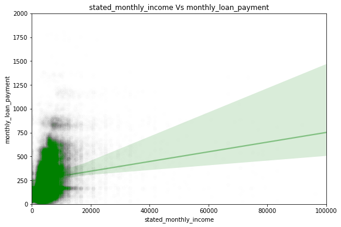

Observation:

- The Borrowers are capable of paying back the higher loan amount when thier income is higher.

## Multivariate Exploration

In this section, we will continue our exploration for multiple variables i.e, more than two varibles and see how 3 different varibales are related

##### Visualization 19:

`loan_original_amount` vs `borrower_APR` vs `term`

Question: How does the feature `term` has an impact on the `loan_original_amount` and `borrower_APR`?

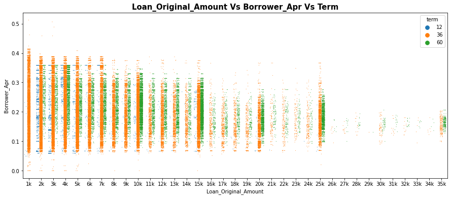

Observation:

- The `borrower_APR` percentage for the loan `term` of 36 months lies between the range of 0 and 0.5. But the percentage rate are densed between 0.05 and 0.4 for most of the loan amounts.
- Whereas the `borrower_APR` percentage for the loan `term` of 60 months lies between the range of 0.09 and 0.36. All the percentage rate lies with this range without any outliers.
- Finally the `borrower_APR` percentage for the loan `term` of 12 months lies between the range of 0.05 and 0.36. But the amount of loan for 12 months `term` is very less while comparing with 36 and 60 months.

##### Visualization 20:

`loan_original_amount` vs `monthly_loan_payment` vs `term`

Question: What will be the monthly loan repayment for different terms?

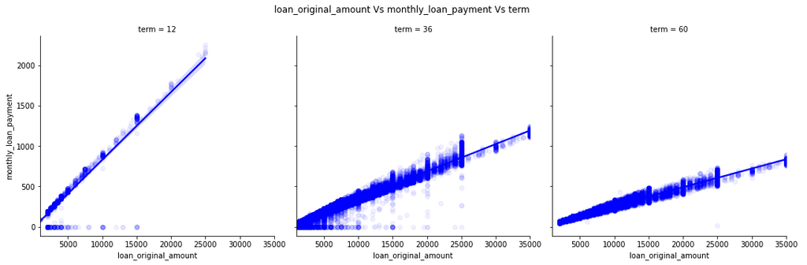

Observation: